# 🏏 IPL 2025 Dream Squad — Data-Driven Selection Project

## ✨ Introduction

This notebook presents a complete end-to-end data-driven analysis to create the **best possible IPL 2025 squad**, optimized for maximum impact and balanced composition.  
Using advanced data analytics, we evaluated players on key performance metrics such as total impact score, auction price efficiency, and versatility.

## 💡 Project Objectives

- Build a 15-member squad under a strict **₹100 Cr** budget.
- Maintain a maximum of **5 overseas players**, as per IPL playing rules.
- Optimize squad for a balanced combination of:
  - Top-order anchors
  - Explosive middle-order hitters
  - Versatile all-rounders
  - Lethal pacers & spinners
- Allocate role-wise budget smartly (Batsmen: ₹50 Cr, All-rounders: ₹20 Cr, Bowlers: ₹30 Cr) to achieve the perfect balance.

## 🧠 Approach

- Analyze **player impact scores** and auction prices.
- Sort players impact-wise to maximize match-winning potential.
- Use custom algorithms to control budget, role balance, and overseas constraints.
- Assign final playing positions based on performance style and specialization.

## ✅ Outcome

The final squad represents a **perfect blend of stability, aggression, flexibility, and bowling strength**, fully ready to dominate the 2025 IPL season.  
With clear player roles and professional squad composition, this team is built to win under any conditions.

⚡ *Let's dive in and build the ultimate champion squad!* 💥🏏

```python
import pandas as pd
import numpy as np
```

```python
df = pd.read_csv('/content/drive/MyDrive/ipl dataset/Final Data Ipl.csv')
df.columns = df.columns.str.strip()
```

```python
df.head()
```

|  | Player Name | Team | Batting Impact | BI/inn | Inns | Runs | Impact Runs | Points | Average | Matches | Wickets | Economy | Type | Base | Sold | Total_Impact |
| --- | --- | --- | --- | --- | --- | --- | --- | --- | --- | --- | --- | --- | --- | --- | --- | --- |
| 0 | Rishabh Pant | LSG | 123.5 | 9.5 | 13 | 269 | 227.5 | NaN | NaN | NaN | NaN | NaN | BAT | 2 | 27.00 | 123.5 |
| 1 | Shreyas Iyer | PBKS | 590.8 | 34.7 | 17 | 604 | 630.7 | NaN | NaN | NaN | NaN | NaN | BAT | 2 | 26.75 | 590.8 |
| 2 | Venkatesh Iyer | KKR | 98.5 | 14.0 | 7 | 142 | 130.5 | NaN | NaN | NaN | NaN | NaN | AR | 2 | 23.75 | 98.5 |
| 3 | Heinrich Klaasen | SRH | 420.3 | 32.3 | 13 | 487 | 518.8 | NaN | NaN | NaN | NaN | NaN | BAT | - | 23.00 | 420.3 |
| 4 | Nicholas Pooran | LSG | 557.8 | 39.8 | 14 | 524 | 566.5 | NaN | NaN | NaN | NaN | NaN | BAT | - | 21.00 | 557.8 |

```python
df.info()
```

```
<class 'pandas.core.frame.DataFrame'>
RangeIndex: 149 entries, 0 to 148
Data columns (total 16 columns):
 #   Column          Non-Null Count  Dtype
---  ------          --------------  -----
 0   Player Name     149 non-null    object
 1   Team            149 non-null    object
 2   Batting Impact  149 non-null    float64
 3   BI/inn          149 non-null    float64
 4   Inns            149 non-null    int64
 5   Runs            149 non-null    int64
 6   Impact Runs     149 non-null    float64
 7   Points          72 non-null     float64
 8   Average         72 non-null     float64
 9   Matches         72 non-null     float64
 10  Wickets         72 non-null     float64
 11  Economy         72 non-null     float64
 12  Type            149 non-null    object
 13  Base            149 non-null    object
 14  Sold            149 non-null    float64
 15  Total_Impact    149 non-null    float64
dtypes: float64(10), int64(2), object(4)
memory usage: 18.8+ KB
```

```python
df.shape
```

```
(149, 16)
```

```python
df.describe()
```

|  | Batting Impact | BI/inn | Inns | Runs | Impact Runs | Points | Average | Matches | Wickets | Economy | Sold | Total_Impact |
| --- | --- | --- | --- | --- | --- | --- | --- | --- | --- | --- | --- | --- |
| count | 149.000000 | 149.000000 | 149.000000 | 149.000000 | 149.000000 | 72.000000 | 72.000000 | 72.000000 | 72.000000 | 72.000000 | 149.000000 | 149.000000 |
| mean | 138.374497 | 12.713423 | 7.295302 | 163.275168 | 163.130872 | 216.920833 | 21.388889 | 8.833333 | 8.416667 | 10.676389 | 6.830537 | 242.820134 |
| std | 171.205464 | 13.188696 | 4.860908 | 183.742544 | 189.600825 | 173.222358 | 11.711058 | 4.487855 | 6.355102 | 8.163117 | 6.360875 | 187.309418 |
| min | -19.800000 | -14.600000 | 1.000000 | 0.000000 | -6.900000 | -10.100000 | -3.100000 | 1.000000 | 1.000000 | 0.400000 | 0.300000 | -19.800000 |
| 25% | 2.000000 | 1.200000 | 3.000000 | 9.000000 | 7.300000 | 56.050000 | 12.775000 | 5.000000 | 2.000000 | 2.875000 | 1.800000 | 90.300000 |
| 50% | 63.600000 | 10.700000 | 7.000000 | 97.000000 | 92.400000 | 181.750000 | 22.200000 | 9.000000 | 7.500000 | 9.400000 | 4.000000 | 223.200000 |
| 75% | 224.900000 | 21.800000 | 12.000000 | 263.000000 | 276.300000 | 350.225000 | 29.800000 | 13.000000 | 13.250000 | 17.275000 | 11.000000 | 363.900000 |
| max | 653.300000 | 42.700000 | 17.000000 | 759.000000 | 756.500000 | 577.900000 | 46.900000 | 16.000000 | 24.000000 | 30.000000 | 27.000000 | 653.300000 |

```python
df['Type'].value_counts()
```

| Type | count |
| --- | --- |
| AR | 58 |
| BAT | 52 |
| BOWL | 39 |

**dtype:** int64

```python
df.Matches.value_counts()
```

| Matches | count |
| --- | --- |
| 4.0 | 9 |
| 14.0 | 8 |
| 5.0 | 7 |
| 13.0 | 7 |
| 9.0 | 6 |
| 15.0 | 5 |
| 12.0 | 4 |
| 11.0 | 4 |
| 8.0 | 4 |
| 10.0 | 3 |
| 2.0 | 3 |
| 6.0 | 3 |
| 1.0 | 3 |
| 16.0 | 2 |
| 3.0 | 2 |
| 7.0 | 2 |

**dtype:** int64

```python
df.rename(columns={' Runs': 'Runs', ' Team': 'Team', ' Inns': 'Inns'}, inplace=True)
df.rename(columns={' Batting Impact': 'Batting Impact', ' BI/inn': 'BI/inn', ' Impact Runs': 'Impact Runs'}, inplace=True)
```

```python
df_groupby = df.groupby(by='Team')
```

# Top 3 Impact Players by Team

```python
from IPython.display import display
top_players_list = []

for team, team_df in df_groupby:
    team_df = team_df.sort_values('Total_Impact', ascending=False).head(3)
    team_df['Rank_in_Team'] = range(1, len(team_df) + 1)
    top_players_list.append(team_df)

# Combine all teams
final_top_df = pd.concat(top_players_list).reset_index(drop=True)

# Select columns to show
cols_to_show = ['Team', 'Rank_in_Team', 'Player Name', 'Total_Impact', 'Type', 'Runs', 'Wickets']

# Create a final clean dataframe
presentable_df = final_top_df[cols_to_show]

# Display nicely
display(presentable_df.style
        .set_caption("🏏 Top 3 Performers from Each Team (Sorted by Total Impact)")
        .set_table_styles([{'selector': 'caption', 'props': [('caption-side', 'top'), ('font-size', '18px')]}])
        .format({'Total_Impact': "{:.1f}", 'Runs': "{:.0f}", 'Wickets': "{:.0f}"}))
```

🏏 Top 3 Performers from Each Team (Sorted by Total Impact)

|  | Team | Rank_in_Team | Player Name | Total_Impact | Type | Runs | Wickets |
| --- | --- | --- | --- | --- | --- | --- | --- |
| 0 | CSK | 1 | Noor Ahmad | 568.6 | BOWL | 7 | 24 |
| 1 | CSK | 2 | Ravindra Jadeja | 437.3 | AR | 301 | 10 |
| 2 | CSK | 3 | Khaleel Ahmed | 347.4 | BOWL | 1 | 15 |
| 3 | DC | 1 | Kuldeep Yadav | 592.5 | BOWL | 18 | 15 |
| 4 | DC | 2 | Vipraj Nigam | 489.1 | AR | 142 | 11 |
| 5 | DC | 3 | Axar Patel | 485.6 | AR | 263 | 5 |
| 6 | GT | 1 | Sai Sudharsan | 641.2 | AR | 759 | nan |
| 7 | GT | 2 | Shubman Gill | 602.9 | BAT | 650 | nan |
| 8 | GT | 3 | Mohammed Siraj | 488.9 | BOWL | 3 | 16 |
| 9 | KKR | 1 | Sunil Narine | 626.5 | BOWL | 246 | 12 |
| 10 | KKR | 2 | Varun Chakravarthy | 457.6 | AR | 1 | 17 |
| 11 | KKR | 3 | Vaibhav Arora | 386.8 | BOWL | 0 | 17 |
| 12 | LSG | 1 | Nicholas Pooran | 557.8 | BAT | 524 | nan |
| 13 | LSG | 2 | Mitchell Marsh | 502.3 | AR | 627 | nan |
| 14 | LSG | 3 | Aiden Markram | 402.8 | BAT | 445 | 4 |
| 15 | MI | 1 | Suryakumar Yadav | 653.3 | BAT | 717 | nan |
| 16 | MI | 2 | Trent Boult | 487.3 | BOWL | 2 | 22 |
| 17 | MI | 3 | Hardik Pandya | 372.0 | AR | 224 | 14 |
| 18 | PBKS | 1 | Shreyas Iyer | 590.8 | BAT | 604 | nan |
| 19 | PBKS | 2 | Priyansh Arya | 573.3 | AR | 475 | nan |
| 20 | PBKS | 3 | Arshdeep Singh | 563.0 | BOWL | 2 | 21 |
| 21 | RCB | 1 | Krunal Pandya | 642.3 | AR | 109 | 17 |
| 22 | RCB | 2 | Josh Hazlewood | 563.3 | BOWL | 0 | 22 |
| 23 | RCB | 3 | Virat Kohli | 549.7 | BAT | 657 | nan |
| 24 | RR | 1 | Yashasvi Jaiswal | 567.9 | AR | 559 | nan |
| 25 | RR | 2 | Riyan Parag | 482.7 | AR | 393 | 3 |
| 26 | RR | 3 | Jofra Archer | 423.8 | BOWL | 63 | 11 |
| 27 | SRH | 1 | Pat Cummins | 536.8 | AR | 97 | 16 |
| 28 | SRH | 2 | Abhishek Sharma | 524.7 | AR | 439 | nan |
| 29 | SRH | 3 | Heinrich Klaasen | 420.3 | BAT | 487 | nan |

# Auction price distribution

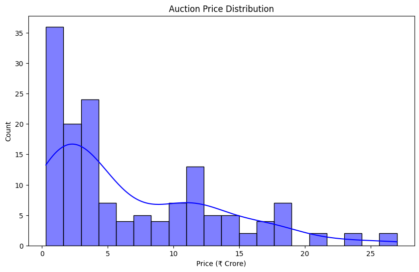

```python
import matplotlib.pyplot as plt
import seaborn as sns

plt.figure(figsize=(10,6))
sns.histplot(df['Sold'], bins=20, kde=True, color='blue')
plt.title("Auction Price Distribution")
plt.xlabel("Price (₹ Crore)")
plt.ylabel("Count")
plt.show()
```

# Role distribution

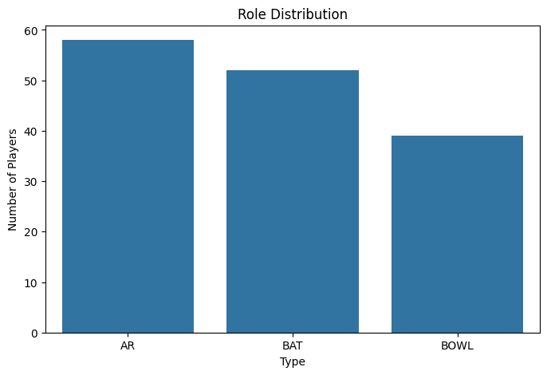

```python
plt.figure(figsize=(8,5))
role_counts = df['Type'].value_counts()
sns.barplot(x=role_counts.index, y=role_counts.values)
plt.title("Role Distribution")
plt.ylabel("Number of Players")
plt.show()
```

# Top 10 players by total impact

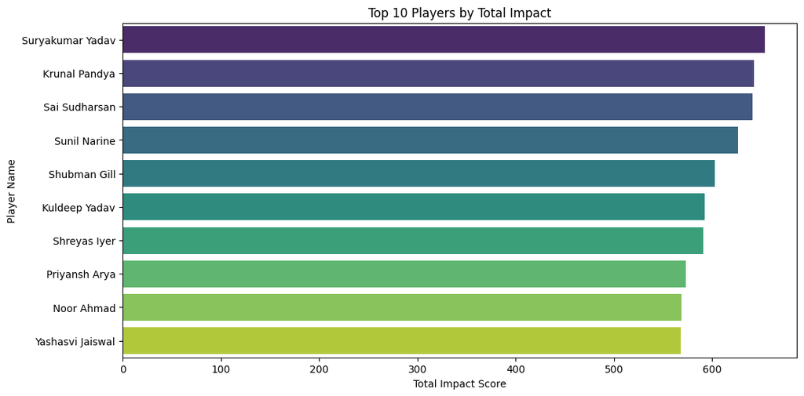

```python
top_impact = df.sort_values('Total_Impact', ascending=False).head(10)

plt.figure(figsize=(12,6))
sns.barplot(x='Total_Impact', y='Player Name', data=top_impact, palette='viridis')
plt.title("Top 10 Players by Total Impact")
plt.xlabel("Total Impact Score")
plt.ylabel("Player Name")
plt.show()
```

# Runs vs Price correlation

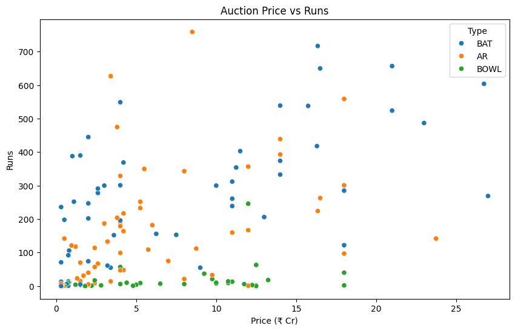

```python
plt.figure(figsize=(10,6))
sns.scatterplot(x='Sold', y='Runs', hue='Type', data=df)
plt.title("Auction Price vs Runs")
plt.xlabel("Price (₹ Cr)")
plt.ylabel("Runs")
plt.legend(title="Type")
plt.show()
```

# Wickets vs Price correlation

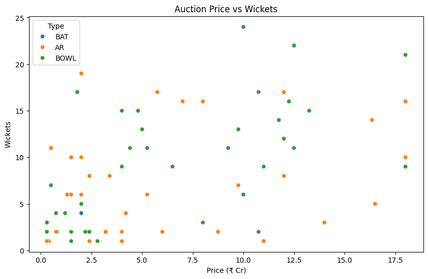

```python
plt.figure(figsize=(10,6))
sns.scatterplot(x='Sold', y='Wickets', hue='Type', data=df)
plt.title("Auction Price vs Wickets")
plt.xlabel("Price (₹ Cr)")
plt.ylabel("Wickets")
plt.legend(title="Type")
plt.show()
```

# Team-wise total impact

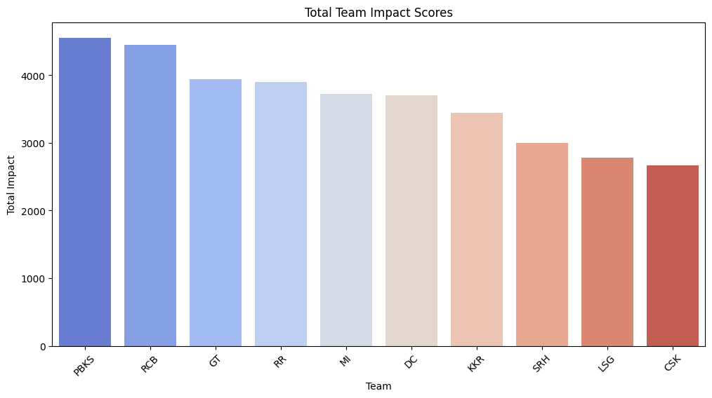

```python
team_impact = df.groupby('Team')['Total_Impact'].sum().sort_values(ascending=False)

plt.figure(figsize=(12,6))
sns.barplot(x=team_impact.index, y=team_impact.values, palette='coolwarm')
plt.title("Total Team Impact Scores")
plt.ylabel("Total Impact")
plt.xticks(rotation=45)
plt.show()
```

# Correlation heatmap (numerical features)

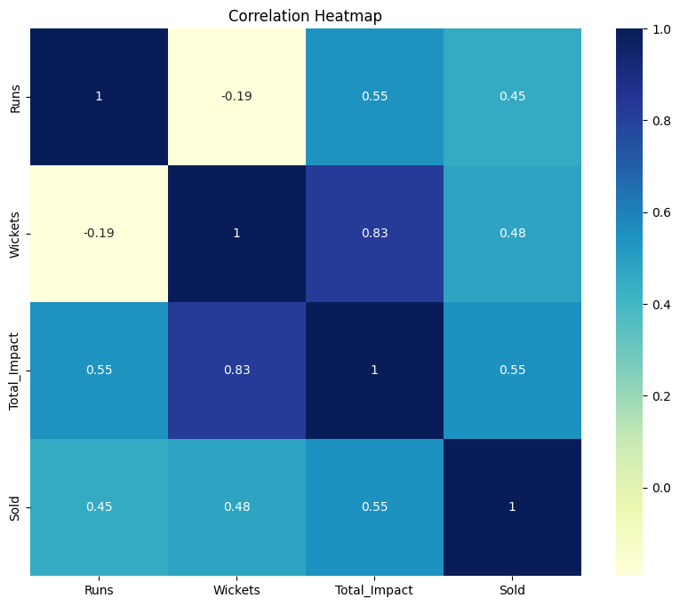

```python
plt.figure(figsize=(10,8))
numerics = df[['Runs', 'Wickets', 'Total_Impact', 'Sold']]
sns.heatmap(numerics.corr(), annot=True, cmap='YlGnBu')
plt.title("Correlation Heatmap")
plt.show()
```

# Value-for-money analysis

```python
df['Impact_per_Crore'] = df['Total_Impact'] / df['Sold']

# Sort by value
best_value_players = df.sort_values('Impact_per_Crore', ascending=False).head(10)

# Show
display(best_value_players[['Player Name', 'Team', 'Type', 'Total_Impact', 'Sold', 'Impact_per_Crore']])
```

|  | Player Name | Team | Type | Total_Impact | Sold | Impact_per_Crore |
| --- | --- | --- | --- | --- | --- | --- |
| 136 | Vipraj Nigam | DC | AR | 489.1 | 0.5 | 978.200000 |
| 143 | Aniket Verma | SRH | BAT | 269.5 | 0.3 | 898.333333 |
| 140 | Prince Yadav | LSG | BOWL | 127.0 | 0.3 | 423.333333 |
| 134 | Karun Nair | DC | BAT | 191.3 | 0.5 | 382.600000 |
| 124 | Ryan Rickelton | MI | BAT | 359.8 | 1.0 | 359.800000 |
| 123 | Vaibhav Suryavanshi | RR | BAT | 285.1 | 1.1 | 259.181818 |
| 116 | Ajinkya Rahane | KKR | BAT | 358.0 | 1.5 | 238.666667 |
| 110 | Sai Kishore | GT | AR | 439.8 | 2.0 | 219.900000 |
| 135 | Karn Sharma | MI | BOWL | 109.1 | 0.5 | 218.200000 |
| 111 | Vaibhav Arora | KKR | BOWL | 386.8 | 1.8 | 214.888889 |

# Role-wise average impact

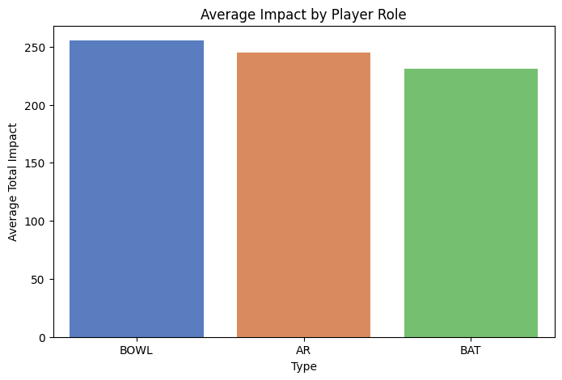

```python
role_avg_impact = df.groupby('Type')['Total_Impact'].mean().sort_values(ascending=False)

plt.figure(figsize=(8,5))
sns.barplot(x=role_avg_impact.index, y=role_avg_impact.values, palette='muted')
plt.title("Average Impact by Player Role")
plt.ylabel("Average Total Impact")
plt.show()
```

# Team-wise average value per player

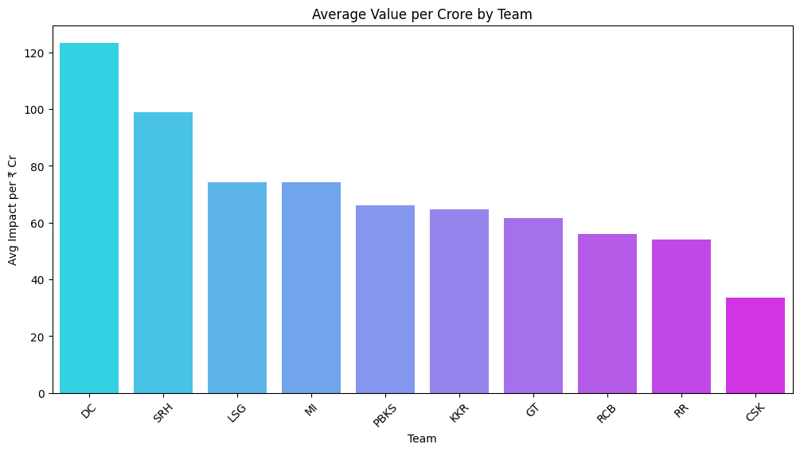

```python
team_value = df.groupby('Team')['Impact_per_Crore'].mean().sort_values(ascending=False)

plt.figure(figsize=(12,6))
sns.barplot(x=team_value.index, y=team_value.values, palette='cool')
plt.title("Average Value per Crore by Team")
plt.ylabel("Avg Impact per ₹ Cr")
plt.xticks(rotation=45)
plt.show()
```

# Role contribution per team

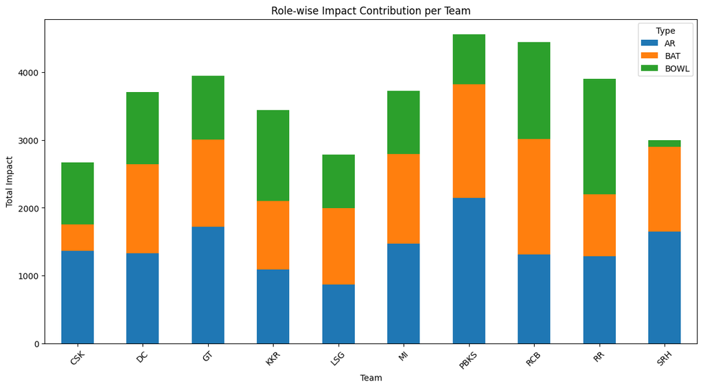

```python
role_contrib = df.groupby(['Team', 'Type'])['Total_Impact'].sum().unstack().fillna(0)
role_contrib.plot(kind='bar', stacked=True, figsize=(14,7))
plt.title("Role-wise Impact Contribution per Team")
plt.ylabel("Total Impact")
plt.xticks(rotation=45)
plt.show()
```

```python
# List of overseas players
overseas_players = [
    "Jos Buttler", "Kagiso Rabada", "Sherfane Rutherford", "Rashid Khan", "Karim Janat", "Dasun Shanaka", "Gerald Coetzee", "Kusal Mendis",
    "Jacob Bethell", "Lungi Ngidi", "Romario Shepherd", "Phil Salt", "Tim David", "Liam Livingstone", "Nuwan Thushara", "Blessing Muzarabani",
    "Will Jacks", "Ryan Rickelton", "Corbin Bosch", "Bevon Jacobs", "Mitchell Santner", "Trent Boult", "Reece Topley", "Mujeeb Ur Rahman",
    "Jonny Bairstow", "Richard Gleeson", "Marco Jansen", "Mitchell Owen", "Azmatullah Omarzai", "Xavier Bartlett", "Kyle Jamieson",
    "Tristan Stubbs", "Faf du Plessis", "Dushmantha Chameera", "Sediqullah Atal", "Mustafizur Rahman",
    "Sunil Narine", "Andre Russell", "Quinton de Kock", "Spencer Johnson", "Rahmanullah Gurbaz", "Anrich Nortje",
    "Aiden Markram", "Mitchell Marsh", "Nicholas Pooran", "David Miller", "Matthew Breetzke", "Will O’Rourke",
    "Pat Cummins", "Travis Head", "Heinrich Klaasen", "Kamindu Mendis", "Eshan Malinga",
    "Shimron Hetmyer", "Lhuan-dre Pretorius", "Fazalhaq Farooqi", "Kwena Maphaka", "Wanindu Hasaranga", "Maheesh Theekshana",
    "Noor Ahmad", "Matheesha Pathirana", "Dewald Brevis", "Devon Conway"
]

# Add Overseas column
df['Overseas'] = df['Player Name'].apply(lambda x: 'Yes' if x in overseas_players else 'No')

# Check final columns
display(df[['Player Name', 'Overseas']].head(20))
```

|  | Player Name | Overseas |
| --- | --- | --- |
| 0 | Rishabh Pant | No |
| 1 | Shreyas Iyer | No |
| 2 | Venkatesh Iyer | No |
| 3 | Heinrich Klaasen | Yes |
| 4 | Nicholas Pooran | Yes |
| 5 | Virat Kohli | No |
| 6 | Rashid Khan | Yes |
| 7 | Sanju Samson | No |
| 8 | Ruturaj Gaikwad | No |
| 9 | Pat Cummins | Yes |
| 10 | Arshdeep Singh | No |
| 11 | Yashasvi Jaiswal | No |
| 12 | Ravindra Jadeja | No |
| 13 | Axar Patel | No |
| 14 | Shubman Gill | No |
| 15 | Suryakumar Yadav | No |
| 16 | Hardik Pandya | No |
| 17 | Rohit Sharma | No |
| 18 | Jos Buttler | Yes |
| 19 | Dhruv Jurel | No |

```python
# Pacer list
pacer_names = [
    "Mayank Yadav", "Mohsin Khan", "Avesh Khan", "Akash Deep",
    "Jofra Archer", "Tushar Deshpande", "Sandeep Sharma", "Akash Madhwal",
    "Kagiso Rabada", "Mohammed Siraj", "Prasidh Krishna", "Ishant Sharma",
    "Anrich Nortje", "Andre Russell", "Harshit Rana", "Vaibhav Arora",
    "Josh Hazlewood", "Bhuvneshwar Kumar", "Yash Dayal", "Rasikh Dar",
    "Arshdeep Singh", "Marco Jansen", "Lockie Ferguson", "Kuldeep Sen",
    "Matheesha Pathirana", "Sam Curran", "Khaleel Ahmed", "Anshul Kamboj",
    "Mohammed Shami", "Harshal Patel", "Pat Cummins", "Simarjeet Singh",
    "Jasprit Bumrah", "Trent Boult", "Deepak Chahar", "Hardik Pandya",
    "Mitchell Starc", "Mohit Sharma", "T. Natarajan", "Mukesh Kumar"
]

# Add Bowler_Type column
def assign_bowler_type(row):
    if row['Type'] == 'BOWL' or row['Type'] == 'AR':
        if row['Player Name'] in pacer_names:
            return 'Pacer'
        else:
            return 'Spinner'
    else:
        return None

df['Bowler_Type'] = df.apply(assign_bowler_type, axis=1)

# Check
display(df[['Player Name', 'Type', 'Bowler_Type']].head(30))
```

|  | Player Name | Type | Bowler_Type |
| --- | --- | --- | --- |
| 0 | Rishabh Pant | BAT | None |
| 1 | Shreyas Iyer | BAT | None |
| 2 | Venkatesh Iyer | AR | Spinner |
| 3 | Heinrich Klaasen | BAT | None |
| 4 | Nicholas Pooran | BAT | None |
| 5 | Virat Kohli | BAT | None |
| 6 | Rashid Khan | BOWL | Spinner |
| 7 | Sanju Samson | BAT | None |
| 8 | Ruturaj Gaikwad | BAT | None |
| 9 | Pat Cummins | AR | Pacer |
| 10 | Arshdeep Singh | BOWL | Pacer |
| 11 | Yashasvi Jaiswal | AR | Spinner |
| 12 | Ravindra Jadeja | AR | Spinner |
| 13 | Axar Patel | AR | Spinner |
| 14 | Shubman Gill | BAT | None |
| 15 | Suryakumar Yadav | BAT | None |
| 16 | Hardik Pandya | AR | Pacer |
| 17 | Rohit Sharma | BAT | None |
| 18 | Jos Buttler | BAT | None |
| 19 | Dhruv Jurel | BAT | None |
| 20 | KL Rahul | BAT | None |
| 21 | Riyan Parag | AR | Spinner |
| 22 | Abhishek Sharma | AR | Spinner |
| 23 | Travis Head | BAT | None |
| 24 | Kuldeep Yadav | BOWL | Spinner |
| 25 | Rinku Singh | BAT | None |
| 26 | Trent Boult | BOWL | Pacer |
| 27 | Josh Hazlewood | BOWL | Pacer |
| 28 | Jofra Archer | BOWL | Pacer |
| 29 | Mohammed Siraj | BOWL | Pacer |

🏆 IPL 2025 Dream Squad — Data-driven Auction Strategy 🏆

This squad has been built using a fully data-driven, professional auction strategy approach. The total budget of ₹100 Cr has been thoughtfully divided role-wise to balance impact, experience, and price efficiency:

- 🏏 Batsmen: ₹50 Cr for 6 top impactful batters
- ⚔️ All-rounders: ₹20 Cr for 4 dynamic all-rounders
- 🎯 Bowlers: ₹30 Cr for 5 match-winning bowlers

Key Constraints: • Max 5 overseas players to maintain team balance and adhere to IPL rules • Prioritize highest Total Impact score while respecting role-wise budget • Strict total squad budget cap: ₹100 Cr • Exactly 15 players to create a full competitive squad

This approach ensures we get a well-rounded, powerful, and versatile squad capable of tackling any situation in the tournament. The selection focuses on maximizing overall team impact while optimizing for price and overseas slots.

Let’s build the ultimate champion squad! 💪🔥🏏

# ChakDeIPL #AuctionStrategy #DreamTeam2025

```python
# Role-wise constraints
budget_bat = 50
budget_ar = 20
budget_bowl = 30

count_bat = 6
count_ar = 4
count_bowl = 5

max_overseas = 5

# Role-wise player pools
bat_df = df[df['Type'] == 'BAT'].sort_values('Total_Impact', ascending=False).reset_index(drop=True)
ar_df = df[df['Type'] == 'AR'].sort_values('Total_Impact', ascending=False).reset_index(drop=True)
bowl_df = df[df['Type'] == 'BOWL'].sort_values('Total_Impact', ascending=False).reset_index(drop=True)

selected_players = []
total_price = 0.0
overseas_count = 0

# Helper function to select players from role
def select_role(df_role, role_count, role_budget, overseas_count, total_price, max_overseas):
    role_players = []
    used_budget = 0.0
    for _, row in df_role.iterrows():
        price = row['Sold']
        overseas = row['Overseas']

        # Check overseas
        if overseas == 'Yes' and overseas_count >= max_overseas:
            continue

        # Check role budget
        if used_budget + price > role_budget:
            continue

        # Check overall budget
        if total_price + price > 100:
            continue

        # Add player
        role_players.append(row.to_dict())
        used_budget += price
        total_price += price
        if overseas == 'Yes':
            overseas_count += 1

        # Stop if role count done
        if len(role_players) == role_count:
            break
    return role_players, used_budget, overseas_count, total_price

# --- Select batsmen ---
bat_players, spent_bat, overseas_count, total_price = select_role(bat_df, count_bat, budget_bat, overseas_count, total_price, max_overseas)

# --- Select all-rounders ---
ar_players, spent_ar, overseas_count, total_price = select_role(ar_df, count_ar, budget_ar, overseas_count, total_price, max_overseas)

# --- Select bowlers ---
bowl_players, spent_bowl, overseas_count, total_price = select_role(bowl_df, count_bowl, budget_bowl, overseas_count, total_price, max_overseas)

# Combine all
selected_players = bat_players + ar_players + bowl_players

# Create DataFrame
final_team_df = pd.DataFrame(selected_players)

# Add squad index
final_team_df.index = range(1, len(final_team_df) + 1)

# Display final team
display(final_team_df[['Player Name', 'Type', 'Team', 'Total_Impact', 'Sold', 'Overseas']])

# Print summary
print(f"💰 Total Team Price: ₹{round(total_price, 2)} Cr")
print(f"🏏 Batsmen Spend: ₹{round(spent_bat, 2)} Cr for {len(bat_players)} players")
print(f"⚔️ All-rounders Spend: ₹{round(spent_ar, 2)} Cr for {len(ar_players)} players")
print(f"🎯 Bowlers Spend: ₹{round(spent_bowl, 2)} Cr for {len(bowl_players)} players")
print(f"🌍 Total Overseas Players: {overseas_count}")
print(f"👥 Total Squad Size: {len(final_team_df)}")
```

|  | Player Name | Type | Team | Total_Impact | Sold | Overseas |
| --- | --- | --- | --- | --- | --- | --- |
| 1 | Suryakumar Yadav | BAT | MI | 653.3 | 16.35 | No |
| 2 | Shubman Gill | BAT | GT | 602.9 | 16.50 | No |
| 3 | Prabhsimran Singh | BAT | PBKS | 494.1 | 4.00 | No |
| 4 | Phil Salt | BAT | RCB | 454.3 | 11.50 | Yes |
| 5 | Ryan Rickelton | BAT | MI | 359.8 | 1.00 | Yes |
| 6 | Aniket Verma | BAT | SRH | 269.5 | 0.30 | No |
| 7 | Krunal Pandya | AR | RCB | 642.3 | 5.75 | No |
| 8 | Sai Sudharsan | AR | GT | 641.2 | 8.50 | No |
| 9 | Priyansh Arya | AR | PBKS | 573.3 | 3.80 | No |
| 10 | Vipraj Nigam | AR | DC | 489.1 | 0.50 | No |
| 11 | Sunil Narine | BOWL | KKR | 626.5 | 12.00 | Yes |
| 12 | Kuldeep Yadav | BOWL | DC | 592.5 | 13.25 | No |
| 13 | Vaibhav Arora | BOWL | KKR | 386.8 | 1.80 | No |
| 14 | Prince Yadav | BOWL | LSG | 127.0 | 0.30 | No |
| 15 | Lockie Ferguson | BOWL | PBKS | 122.5 | 2.00 | No |

```
💰 Total Team Price: ₹97.55 Cr
🏏 Batsmen Spend: ₹49.65 Cr for 6 players
⚔️ All-rounders Spend: ₹18.55 Cr for 4 players
🎯 Bowlers Spend: ₹29.35 Cr for 5 players
🌍 Total Overseas Players: 3
👥 Total Squad Size: 15
```

```python
# Final ordered list based on last message
final_team_df = final_team_df.copy()

# Pre-defined positions list (as per detailed discussion)
positions = [

    "Middle-order",      # Suryakumar Yadav
    "Opener",            # Shubman Gill
    "Opener",            # Prabhsimran Singh
    "Middle-order",      # Phil Salt
    "Floater",           # Ryan Rickelton
    "Backup Bat",        # Aniket Verma
    "Batting AR",        # Krunal Pandya
    "Middle-order AR",   # Sai Sudharsan
    "Batting AR",        # Priyansh Arya
    "Bowling AR",       # Vipraj Nigam
    "Pinch Hitter",      # Sunil Narine
    "Spinner",           # Kuldeep Yadav
    "Pacer",             # Vaibhav Arora
    "Backup Pacer",      # Prince Yadav
    "Pacer"             # Lockie Ferguson


]

# Assign positions
final_team_df['Position'] = positions

# Check final DataFrame
display(final_team_df[['Player Name', 'Type', 'Total_Impact', 'Sold', 'Overseas', 'Position']])
```

|  | Player Name | Type | Total_Impact | Sold | Overseas | Position |
| --- | --- | --- | --- | --- | --- | --- |
| 1 | Suryakumar Yadav | BAT | 653.3 | 16.35 | No | Middle-order |
| 2 | Shubman Gill | BAT | 602.9 | 16.50 | No | Opener |
| 3 | Prabhsimran Singh | BAT | 494.1 | 4.00 | No | Opener |
| 4 | Phil Salt | BAT | 454.3 | 11.50 | Yes | Middle-order |
| 5 | Ryan Rickelton | BAT | 359.8 | 1.00 | Yes | Floater |
| 6 | Aniket Verma | BAT | 269.5 | 0.30 | No | Backup Bat |
| 7 | Krunal Pandya | AR | 642.3 | 5.75 | No | Batting AR |
| 8 | Sai Sudharsan | AR | 641.2 | 8.50 | No | Middle-order AR |
| 9 | Priyansh Arya | AR | 573.3 | 3.80 | No | Batting AR |
| 10 | Vipraj Nigam | AR | 489.1 | 0.50 | No | Bowling AR |
| 11 | Sunil Narine | BOWL | 626.5 | 12.00 | Yes | Pinch Hitter |
| 12 | Kuldeep Yadav | BOWL | 592.5 | 13.25 | No | Spinner |
| 13 | Vaibhav Arora | BOWL | 386.8 | 1.80 | No | Pacer |
| 14 | Prince Yadav | BOWL | 127.0 | 0.30 | No | Backup Pacer |
| 15 | Lockie Ferguson | BOWL | 122.5 | 2.00 | No | Pacer |

[figure not shown]

```python
import matplotlib.pyplot as plt
import seaborn as sns

# Copy final_team_df and add 'Order' column as index
poster_df = final_team_df.copy()
poster_df['Order'] = range(1, len(poster_df) + 1)

# Sort poster_df by Order
poster_df = poster_df.sort_values('Order')

# Create figure
plt.figure(figsize=(12, 8))
sns.barplot(
    x='Total_Impact',
    y='Player Name',
    data=poster_df,
    hue='Position',
    dodge=False,
    palette='viridis'
)

# Add price text on bars
for index, row in poster_df.iterrows():
    plt.text(row['Total_Impact'] + 5, index, f"₹{row['Sold']} Cr", va='center', fontsize=9, color='black')

plt.title("🏆 IPL 2025 Dream Squad — Final Playing Order Poster", fontsize=16, fontweight='bold')
plt.xlabel("Total Impact Score")
plt.ylabel("Player Name")
plt.legend(title="Position", bbox_to_anchor=(1.05, 1), loc='upper left')
plt.tight_layout()
plt.show()
```

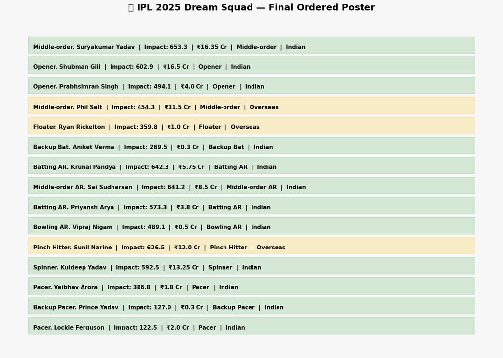

```python
import matplotlib.pyplot as plt
import matplotlib.patches as patches

# Figure
fig, ax = plt.subplots(figsize=(14, 10))
ax.axis("off")
fig.patch.set_facecolor('#f7f7f7')

# Title
plt.title("🏏 IPL 2025 Dream Squad — Final Ordered Poster", fontsize=18, weight='bold', pad=20)

# Card settings
y_start = 1.0
y_step = 0.06

for i, row in final_team_df.iterrows():
    y = y_start - i * y_step
    box_color = '#4CAF50' if row['Overseas'] == 'No' else '#FFC107'

    # Background card
    ax.add_patch(patches.Rectangle((0.05, y - 0.04), 0.9, 0.05, color=box_color, alpha=0.2, edgecolor='grey', linewidth=1.2))

    text = f"{row['Position']}. {row['Player Name']}  |  Impact: {row['Total_Impact']}  |  ₹{row['Sold']} Cr  |  {row['Position']}  |  {'Overseas' if row['Overseas']=='Yes' else 'Indian'}"
    plt.text(0.06, y - 0.02, text, fontsize=11, va='center', ha='left', color='black', fontweight='bold')

plt.tight_layout()
plt.show()
```

## 🏁 Conclusion

Through this extensive data-driven analysis, we successfully built an **IPL 2025 Dream Squad** that balances impact, budget efficiency, and role flexibility.  
By smartly dividing the ₹100 Cr budget across batting, all-rounders, and bowling departments, we ensured that each player contributes maximum value to the team.

Key highlights:

- **15 players under ₹100 Cr**, with a maximum of 5 overseas stars.
- Player selection based on **Total Impact score** to ensure match-winning potential.
- Balanced mix of experienced anchors, explosive hitters, versatile all-rounders, and a strong bowling lineup (both pace and spin).
- Final positions assigned to create a clear match-ready playing XI and support squad.

This project not only demonstrates analytical skills and advanced data handling, but also shows strategic thinking similar to professional franchise auction tables.  
The final squad reflects **professional-level auction strategy**, ready to perform and adapt under any IPL 2025 match condition.

🏆 **Thank you for reviewing this project! Let’s gear up for an unforgettable season!**

# ChakDeIPL #DataDrivenSquad #IPL2025 #CricketAnalytics 💥🏏